# pavo colour analysis tools

Ana Barreira

12/2/2020

This tutorial goes through some of the colour analysis tools for **spectrophotometric** data.  
We will use measurements taken on museum specimens of the Painted Bunting (*Passerina ciris*) at the American Museum of Natural History.

[figure not shown]

*Passerina ciris

Plumage patches: 1) Forehead  
2) Head  
3) Back  
4) Throat  
5) Chest  
6) Belly

I measured each plumage patch 5 times, repositioning the probe on the plumage each time.  
I callibrated agains a WS-1 white standard before measuring each specimen.

```
##           Species    Patch  X ind..   AMNH Subespecie    Sex Spectra.code
## 1 Passerina ciris forehead  1     1 365222      ciris   male    pcis_c_m1
## 2                     head  2     2 365266      ciris female    pcis_c_h1
## 3                     back  3     3 365273      ciris   male    pcis_c_m2
## 4                   throat  4     4 761052      ciris female    pcis_c_h2
## 5                    chest  5     5  54939  pallidior   male    pcis_p_m3
## 6                    belly  6     6 365278  pallidior female    pcis_p_h3
## 7                          NA     7 761057      ciris   male    pcis_c_m4
## 8                          NA     8 761058      ciris female    pcis_c_h4
```

##First step: load spectra + polishing

The pavo package loads and reads as spectra files created by the spectrophotometer (e.g. .spec, .txt). Spectra can also be uploaded from .csv files but need to be formatted with the as.rspec() function. Before proceeding to estimate colour variables and apply visual models we need to polish the data a bit.

```r
library(pavo)
pcir <- getspec("Passerina ciris", ext = "txt", decimal = ".")
```

```
## 240 files found; importing spectra:
```

```r
#check that the files have spectra attributes -> should say true
is.rspec(pcir)
```

```
## [1] TRUE
```

```r
#the spectra include reflectance between 300 - 700 nm and have one reflectance
#value per wavelength (interpolated from the original values).

pcir[100:110, 1:4]
```

```
##      wl pcis_c_h1_p1_Reflection_1 pcis_c_h1_p1_Reflection_2
## 100 399                  13.53834                  13.51332
## 101 400                  13.46958                  13.47567
## 102 401                  13.43000                  13.42617
## 103 402                  13.45317                  13.48158
## 104 403                  13.51808                  13.47128
## 105 404                  13.51856                  13.51142
## 106 405                  13.61950                  13.61950
## 107 406                  13.69000                  13.63189
## 108 407                  13.74250                  13.71150
## 109 408                  13.87000                  13.79661
## 110 409                  13.92613                  13.90000
##     pcis_c_h1_p1_Reflection_3
## 100                  15.97166
## 101                  15.90392
## 102                  15.85767
## 103                  15.86842
## 104                  15.82319
## 105                  15.89714
## 106                  15.99000
## 107                  16.02000
## 108                  16.14000
## 109                  16.20322
## 110                  16.23838
```

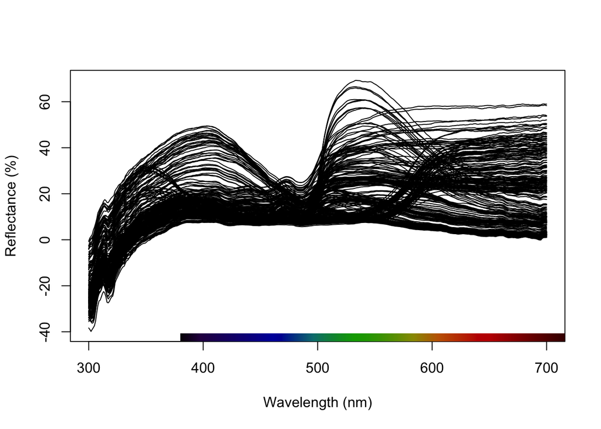

```r
plot(pcir)
```

```r
#Some spectra have negative values on the UV part of the spectrum. This is
#physically impossible, but usually happens. When reflectace is very low,
#reflectance values are noisy. This has to be fixed. There are two options:
#1) add the max absolute negative value and push all the spectra higher (addmin)
#; and 2) replace negative values with zeros

pcir_nonegs <-procspec(pcir, fixneg= "zero")
```

```
## processing options applied:
## Negative value correction: converted negative values to zero
```

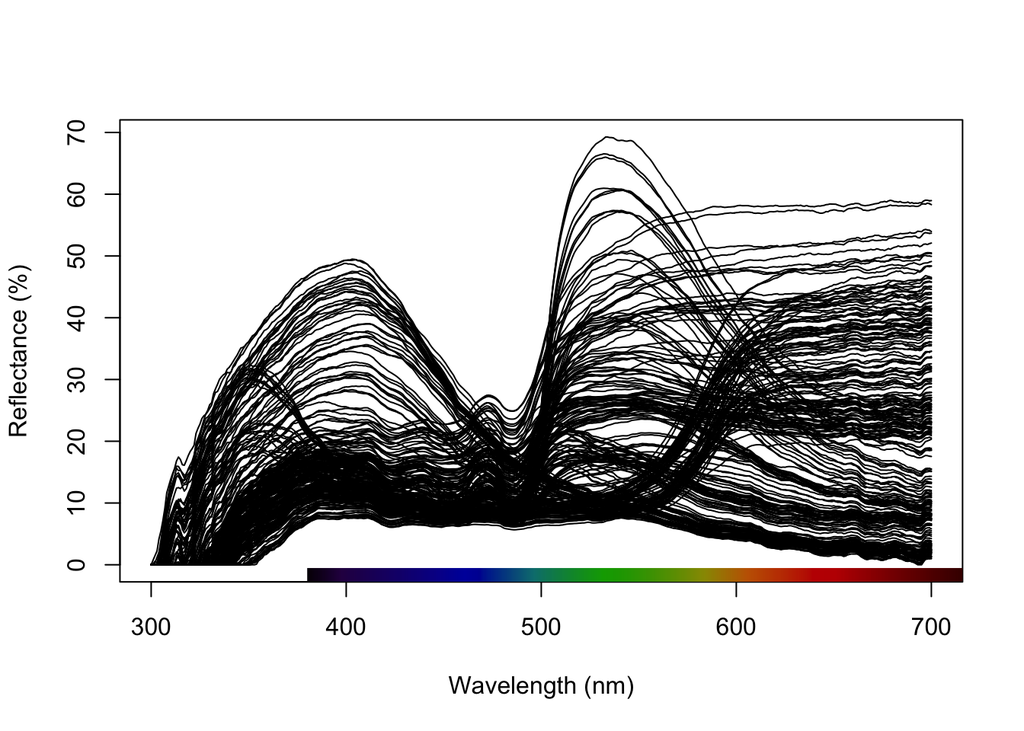

```r
plot(pcir_nonegs)
```

```r
#Now we need to average the 5 repetitions taken for each plumage patch.
#the script will average contiguous columns, so we have to make sure we have
#exactly 5 spectra per plumage patch and individual.
#I measured 8 individuals on 6 patches, so I should end up with 48 spectra.

pcir_mean <- aggspec(pcir_nonegs, by = 5, FUN = mean)
pcir_mean[1:10, 1:5]
```

```
##     wl pcis_c_h1_p1_Reflection pcis_c_h1_p2_Reflection pcis_c_h1_p3_Reflection
## 1  300                       0                       0                       0
## 2  301                       0                       0                       0
## 3  302                       0                       0                       0
## 4  303                       0                       0                       0
## 5  304                       0                       0                       0
## 6  305                       0                       0                       0
## 7  306                       0                       0                       0
## 8  307                       0                       0                       0
## 9  308                       0                       0                       0
## 10 309                       0                       0                       0
##    pcis_c_h1_p4_Reflection
## 1                        0
## 2                        0
## 3                        0
## 4                        0
## 5                        0
## 6                        0
## 7                        0
## 8                        0
## 9                        0
## 10                       0
```

```r
dim(pcir_mean)
```

```
## [1] 401  49
```

```r
#Finally, I want to create subsets groupping all the spectra for the same plumage patch


pcir_p1 <- subset(pcir_mean, "p1")
pcir_p2 <- subset(pcir_mean, "p2")
pcir_p3 <- subset(pcir_mean, "p3")
pcir_p4 <- subset(pcir_mean, "p4")
pcir_p5 <- subset(pcir_mean, "p5")
pcir_p6 <- subset(pcir_mean, "p6")
```

## Step two: Colour description

Now that the spectra are arranged by plumage patch we can estimate variables to describe colour (brightness, hue, chroma or saturation) and graph spectra

```r
#With the aggplot we can plot mean (+/- SE) spectra by groups of samples we
#want to compare. I'll separate by sex in this case

#First I need to create a grouping variable that separates spectra by sex

pcir_p1_sex <-gsub('[^hm]', "", names(pcir_p1))[-1]
table(pcir_p1_sex)
```

```
## pcir_p1_sex
## h m
## 4 4
```

```r
pcir_p2_sex <-gsub('[^hm]', "", names(pcir_p2))[-1]
table(pcir_p2_sex)
```

```
## pcir_p2_sex
## h m
## 4 4
```

```r
pcir_p3_sex <-gsub('[^hm]', "", names(pcir_p3))[-1]
table(pcir_p3_sex)
```

```
## pcir_p3_sex
## h m
## 4 4
```

```r
pcir_p4_sex <-gsub('[^hm]', "", names(pcir_p4))[-1]
table(pcir_p4_sex)
```

```
## pcir_p4_sex
## h m
## 4 4
```

```r
pcir_p5_sex <-gsub('[^hm]', "", names(pcir_p5))[-1]
table(pcir_p5_sex)
```

```
## pcir_p5_sex
## h m
## 4 4
```

```r
pcir_p6_sex <-gsub('[^hm]', "", names(pcir_p6))[-1]
table(pcir_p6_sex)
```

```
## pcir_p6_sex
## h m
## 4 4
```

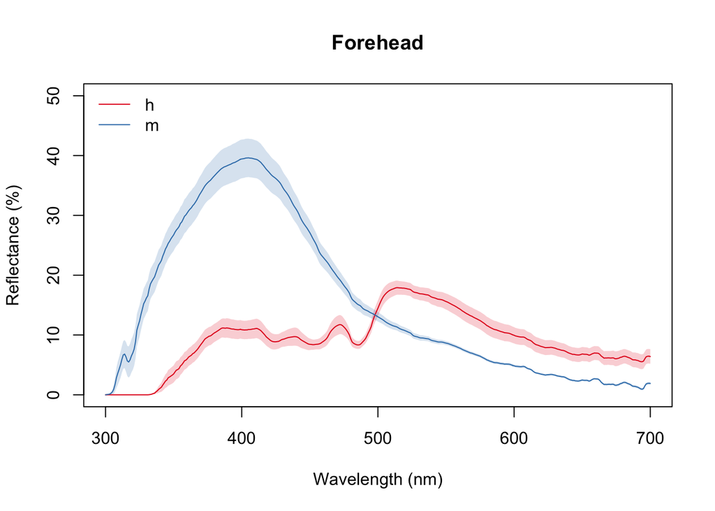

```r
#Now I will plot mean spectra by sex with a shaded area indicating standard
#error

aggplot(pcir_p1, pcir_p1_sex, FUN.error=function(x)sd(x)/sqrt(length(x)),
        legend=TRUE, ylim=c(0,50), main="Forehead")
```

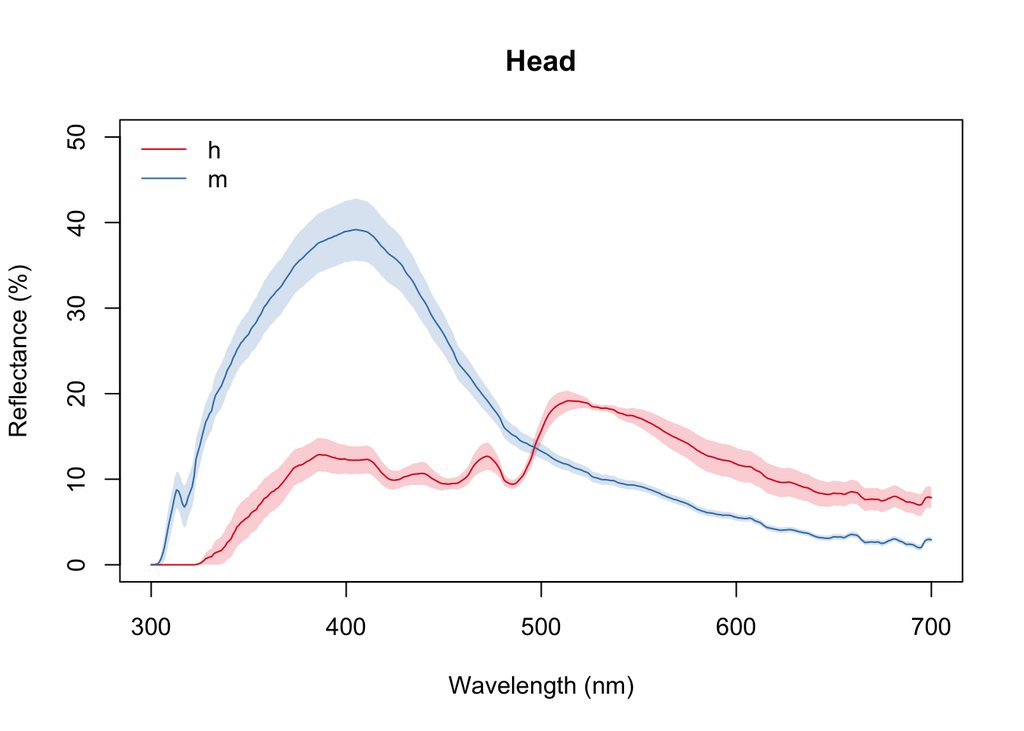

```r
aggplot(pcir_p2, pcir_p2_sex, FUN.error=function(x)sd(x)/sqrt(length(x)),
        legend=TRUE, ylim=c(0,50), main="Head")
```

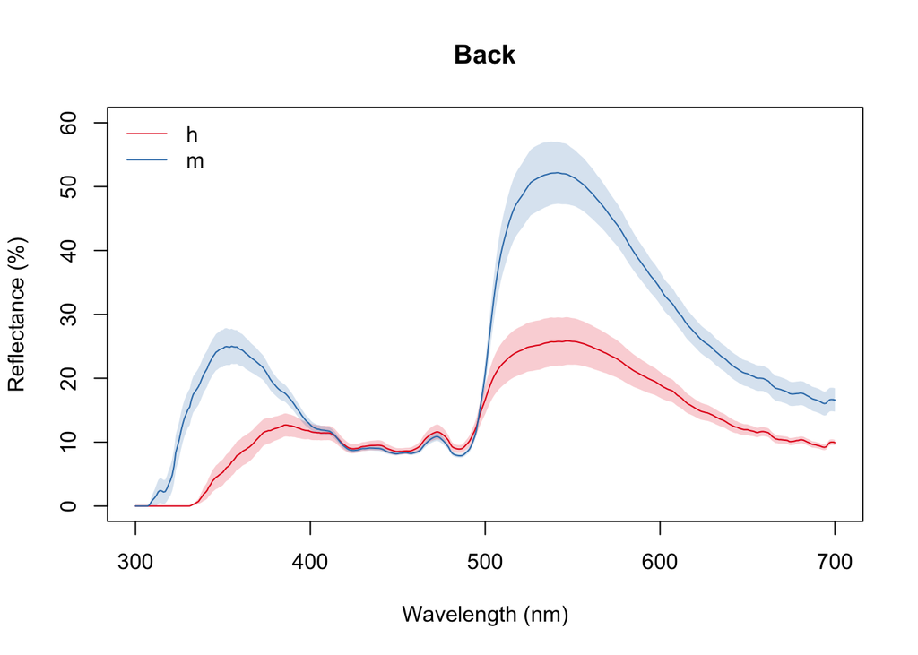

```r
aggplot(pcir_p3, pcir_p3_sex, FUN.error=function(x)sd(x)/sqrt(length(x)),
        legend=TRUE, ylim=c(0,60), main="Back")
```

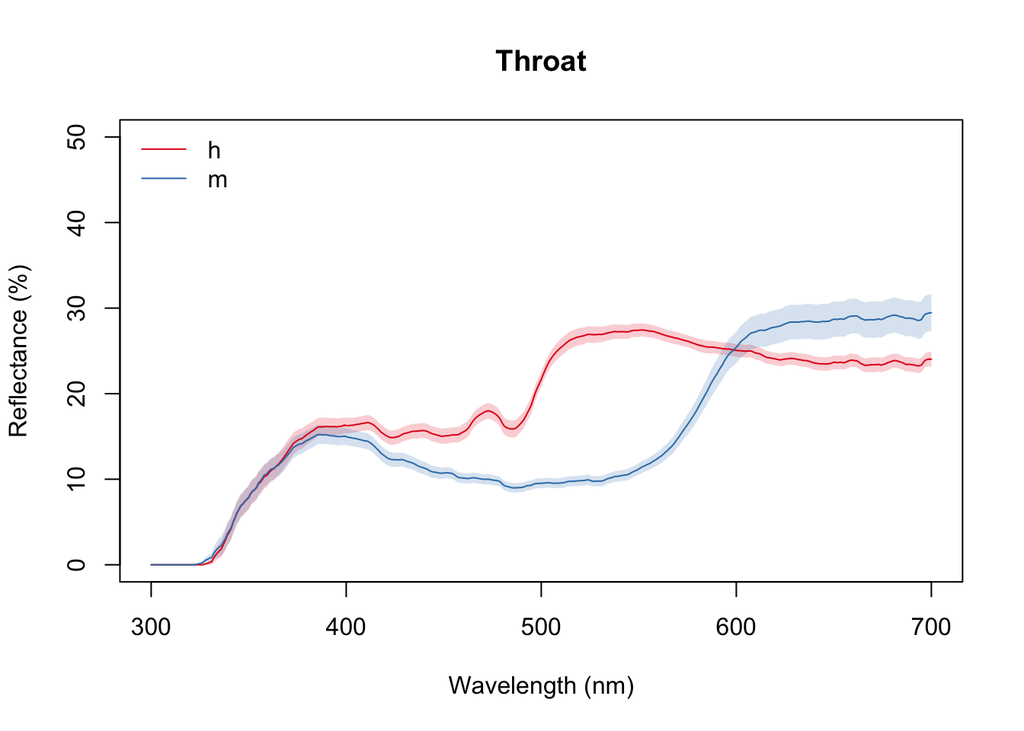

```r
aggplot(pcir_p4, pcir_p4_sex, FUN.error=function(x)sd(x)/sqrt(length(x)),
        legend=TRUE, ylim=c(0,50), main="Throat")
```

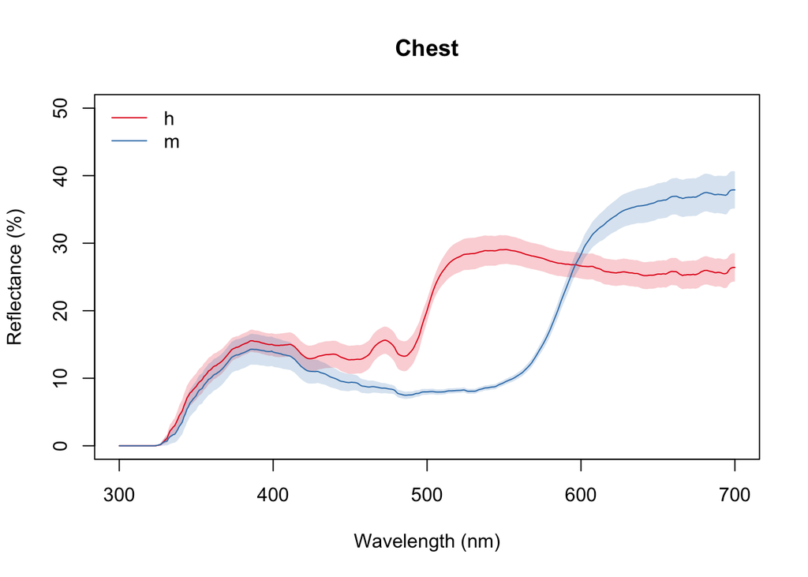

```r
aggplot(pcir_p5, pcir_p5_sex, FUN.error=function(x)sd(x)/sqrt(length(x)),
        legend=TRUE, ylim=c(0,50), main="Chest")
```

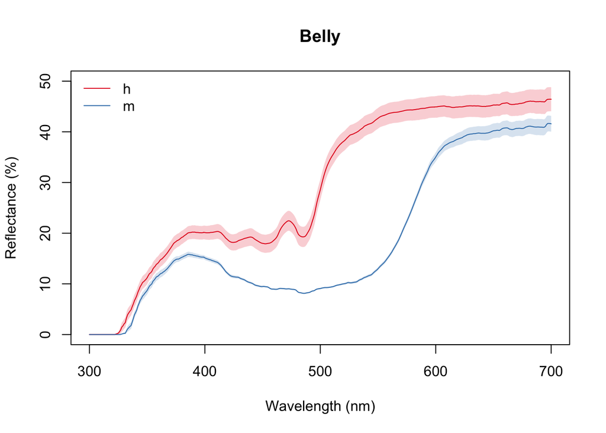

```r
aggplot(pcir_p6, pcir_p6_sex, FUN.error=function(x)sd(x)/sqrt(length(x)),
        legend=TRUE, ylim=c(0,50), main="Belly")
```

```r
#We can extract the values for a large set of spectral variables included in
##pavo. Those values can be exported to a .csv file for further analyses.
##The description of the 23 variables can be found running:

?summary.rspec


##A subset shows only the most commonly used variables.

summary(pcir_mean, subset=TRUE)
```

```
##                                B2       S8  H1
## pcis_c_h1_p1_Reflection  8.724274 2.012515 507
## pcis_c_h1_p2_Reflection 11.390150 1.946633 508
## pcis_c_h1_p3_Reflection 16.581332 2.108051 546
## pcis_c_h1_p4_Reflection 18.378712 1.488568 537
## pcis_c_h1_p5_Reflection 17.687058 1.756308 537
## pcis_c_h1_p6_Reflection 26.398124 1.616960 697
## pcis_c_h2_p1_Reflection  8.594230 2.042112 548
## pcis_c_h2_p2_Reflection 11.049891 1.826443 552
## pcis_c_h2_p3_Reflection  9.132042 1.854927 553
## pcis_c_h2_p4_Reflection 17.477851 1.534558 552
## pcis_c_h2_p5_Reflection 15.662176 1.586133 559
## pcis_c_h2_p6_Reflection 28.263189 1.708323 699
## pcis_c_h4_p1_Reflection  8.768880 2.028813 519
## pcis_c_h4_p2_Reflection  9.482816 1.862727 519
## pcis_c_h4_p3_Reflection 12.566746 2.026178 547
## pcis_c_h4_p4_Reflection 18.116370 1.445696 548
## pcis_c_h4_p5_Reflection 19.574239 1.361075 552
## pcis_c_h4_p6_Reflection 28.493723 1.492587 699
## pcis_c_m1_p1_Reflection 15.350255 2.622627 404
## pcis_c_m1_p2_Reflection 17.323386 2.481740 405
## pcis_c_m1_p3_Reflection 26.837756 2.331074 533
## pcis_c_m1_p4_Reflection 14.306623 2.090452 700
## pcis_c_m1_p5_Reflection 15.646695 2.494095 700
## pcis_c_m1_p6_Reflection 19.739677 2.260947 697
## pcis_c_m2_p1_Reflection 12.022160 2.591962 405
## pcis_c_m2_p2_Reflection 12.312557 2.469052 399
## pcis_c_m2_p3_Reflection 19.165879 2.242631 552
## pcis_c_m2_p4_Reflection 13.886215 2.018724 700
## pcis_c_m2_p5_Reflection 13.165257 2.327371 700
## pcis_c_m2_p6_Reflection 18.460428 2.371932 697
## pcis_c_m4_p1_Reflection 16.347119 2.471077 411
## pcis_c_m4_p2_Reflection 14.943720 2.461260 410
## pcis_c_m4_p3_Reflection 20.118053 2.261531 539
## pcis_c_m4_p4_Reflection 17.730728 1.982022 699
## pcis_c_m4_p5_Reflection 16.633671 2.285695 698
## pcis_c_m4_p6_Reflection 18.464915 2.184149 698
## pcis_p_h3_p1_Reflection 10.228571 2.075168 514
## pcis_p_h3_p2_Reflection  9.881173 2.058217 514
## pcis_p_h3_p3_Reflection 13.577743 1.941075 538
## pcis_p_h3_p4_Reflection 19.912568 1.490457 550
## pcis_p_h3_p5_Reflection 22.141903 1.550839 551
## pcis_p_h3_p6_Reflection 33.429790 1.565659 698
## pcis_p_m3_p1_Reflection 17.786279 2.635352 403
## pcis_p_m3_p2_Reflection 18.611662 2.516709 405
## pcis_p_m3_p3_Reflection 26.160292 2.240378 541
## pcis_p_m3_p4_Reflection 14.610426 1.697805 700
## pcis_p_m3_p5_Reflection 19.152380 2.299135 698
## pcis_p_m3_p6_Reflection 17.970031 2.108462 698
```

##Step three: incorporate visual perception

The colour variables are good to describe colour in a manner that is easy to interpret, but differences in these variables not necessarily imply differences that are biologically meaningful. For that, we can apply avian visual models that integrate reflectance data with visual sensitivity, although it requires making some assumptions.

1. Tetracolour space (TCS)  
   This model transforms colours into point on the tetrahedral colour space of birds. Colour variables can be estimated from the position of every colour in this tetrahedron relative to the maximum sensitivity of the visual system of the receptor.

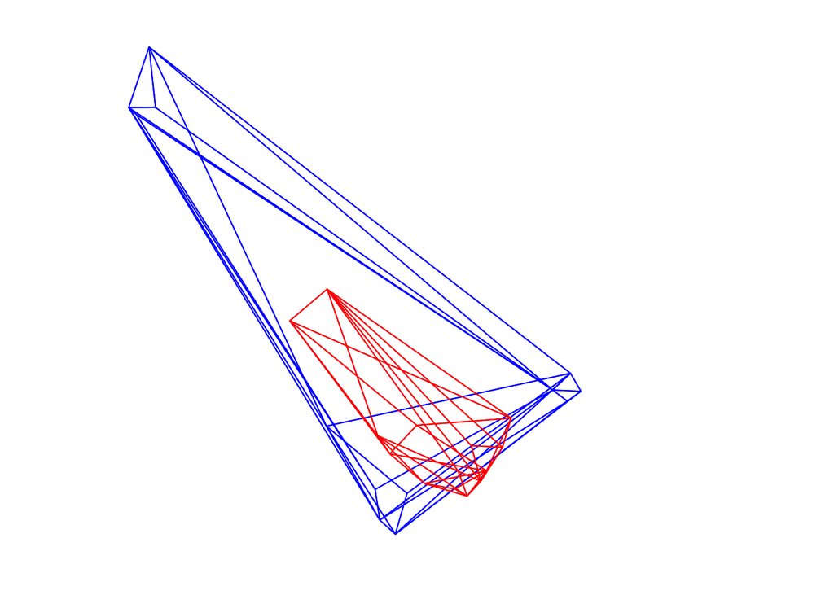

```
##          vol1         vol2 overlapvol vsmallest vboth
## 1 0.003524648 0.0007721856          0         0     0
```

```r
#The first step is to estimate photoreceptor quatum catches. These are a measure
#of the stimulation each photoreceptor receives, based on the reflectance spectra,
#and the physiological parameters of the visual system and the ambient light
#conditions.

#for all plumage patches together
pcir_qc_rel <- vismodel (pcir_mean, visual="avg.uv", achromatic="bt.dc",
                         relative=TRUE, vonkries=TRUE, bkg="ideal")


#The tetrachromatic colour space model (TCS) transforms the quantum catches
#into a point in the tetrahedral colour space diagram.

pcir_tcs <- colspace(pcir_qc_rel, space = c("tcs"))

#the colour points can be plotted. I subset them by sex and plot both sexes on
#the same tetrahedron.

tcs_males <-subset(pcir_tcs, "m")
tcs_females <-subset(pcir_tcs, "h")
tcsplot(tcs_males, col="blue", size = 0.01)
tcspoints(tcs_females, col = "red", size = 0.01)
tcsvol(tcs_females, col = "red")
tcsvol(tcs_males, col= "blue")


#can also calculate and graph the volumen overlapped between groups
voloverlap(tcs_males, tcs_females, plot = TRUE)
```

```r
#TCS estimates variables describing colours in the avian visual space. These are
#harder to interpret, but framed within an avian visual perception model

View(pcir_tcs)

#Description of this variables in the function's description and
#Stoddard and Prum 2008

?tcspace

pcir_sex <-gsub('[^hm]', "", rownames(pcir_tcs))
table(pcir_sex)
```

```
## pcir_sex
##  h  m
## 24 24
```

```r
#with summary we can get summary statistics by groups. The most commonly used
#are Colspan (diversity of colours) and Huedisp (how different are the most
#different colour within the sample)

summary(pcir_tcs, by = pcir_sex)
```

```
## Colorspace & visual model options:
##  * Colorspace: tcs
##  * Quantal catch: Qi
##  * Visual system, chromatic: avg.uv
##  * Visual system, achromatic: bt.dc
##  * Illuminant: ideal, scale = 1 (von Kries colour correction applied)
##  * Background: ideal
##  * Relative: TRUE
##  * Max possible chromatic volume: 0.215735
```

```
##   centroid.u centroid.s centroid.m centroid.l        c.vol   rel.c.vol
## h  0.1383272  0.2079031  0.3646301  0.2891396 0.0007721856 0.003566573
## m  0.2554686  0.2111282  0.2210448  0.3123584 0.0035246484 0.016279654
##   colspan.m   colspan.v huedisp.m huedisp.v   mean.ra    max.ra
## h 0.1020298 0.003680272 0.6127107 0.2567923 0.4816293 0.6142179
## m 0.2920056 0.038121473 1.3975238 1.1011046 0.5515697 0.7737122
```

2. Receptor-noice limited model (RNL, Vorobyev and Osorio 1998)

This model allows to calculate colour differences in terms of JND (Just Noticeable Differences).

```r
#To estimate colour perceptual distances with the RNL we have to use absolute
#quantum catches . I will compare colour between sexes for each
#plumage patch separately. Quantum catches don't have to be relative for this
#calculation (relative=FALSE).

pcir_qc_abs <- vismodel (pcir_mean, visual="avg.uv", achromatic="bt.dc",
                         relative=FALSE, vonkries=TRUE, bkg="ideal")

pcir_qc_p1 <- subset(pcir_qc_abs, "p1")
pcir_qc_p2 <- subset(pcir_qc_abs, "p2")
pcir_qc_p3 <- subset(pcir_qc_abs, "p3")
pcir_qc_p4 <- subset(pcir_qc_abs, "p4")
pcir_qc_p5 <- subset(pcir_qc_abs, "p5")
pcir_qc_p6 <- subset(pcir_qc_abs, "p6")

#The coldist funcion will estimate dS considering some assumed parameters values
#A subset can be specified so the comparisons are made between groups,
#in this case sexes.

pcir_p1_sd <- coldist (pcir_qc_p1, n=c(1,2,2,4), weber=0.1, achromatic = 0.1,
                       subset=c("m", "h"))
```

```
## Calculating noise-weighted Euclidean distances and noise-weighted luminance contrasts
```

```r
pcir_p2_sd <- coldist (pcir_qc_p2, n=c(1,2,2,4), weber=0.1, achromatic = 0.1,
                       subset=c("m", "h"))
```

```
## Calculating noise-weighted Euclidean distances and noise-weighted luminance contrasts
```

```r
pcir_p3_sd <- coldist (pcir_qc_p3, n=c(1,2,2,4), weber=0.1, achromatic = 0.1,
                       subset=c("m", "h"))
```

```
## Calculating noise-weighted Euclidean distances and noise-weighted luminance contrasts
```

```r
pcir_p4_sd <- coldist (pcir_qc_p4, n=c(1,2,2,4), weber=0.1, achromatic = 0.1,
                       subset=c("m", "h"))
```

```
## Calculating noise-weighted Euclidean distances and noise-weighted luminance contrasts
```

```r
pcir_p5_sd <- coldist (pcir_qc_p5, n=c(1,2,2,4), weber=0.1, achromatic = 0.1,
                       subset=c("m", "h"))
```

```
## Calculating noise-weighted Euclidean distances and noise-weighted luminance contrasts
```

```r
pcir_p6_sd <- coldist (pcir_qc_p6, n=c(1,2,2,4), weber=0.1, achromatic = 0.1,
                       subset=c("m", "h"))
```

```
## Calculating noise-weighted Euclidean distances and noise-weighted luminance contrasts
```

```r
#We could calculate the mean of these comparisons and see how they are relative to
#the theoretical perceptual threshold (1 JND). But intra-group differences
#can be very variable and mean dS between groups does not account for
#statistical relevance of the differences between groups
#(see Maia and White, 2018 - Behavioural Ecology). Bootcoldist function allows
#estimating 95% CI and mean dS

#forehead
pcir_qc_bysex_p1<-gsub("[^hm]", "", rownames(pcir_qc_p1))
bootcoldist(pcir_qc_p1, pcir_qc_bysex_p1, n=c(1,2,2,4), weber=0.1,
            weber.achro=0.1)
```

```
##      dS.mean dS.lwr   dS.upr  dL.mean    dL.lwr   dL.upr
## h-m 12.94772 9.3865 15.74449 2.060072 0.6983555 3.601643
```

```r
#head
pcir_qc_bysex_p2<-gsub("[^hm]", "", rownames(pcir_qc_p2))
bootcoldist(pcir_qc_p2, pcir_qc_bysex_p2, n=c(1,2,2,4), weber=0.1,
            weber.achro=0.1)
```

```
##      dS.mean dS.lwr   dS.upr  dL.mean   dL.lwr   dL.upr
## h-m 12.08874 8.9771 15.07352 2.799176 1.406651 4.388718
```

```r
#back
pcir_qc_bysex_p3<-gsub("[^hm]", "", rownames(pcir_qc_p3))
bootcoldist(pcir_qc_p3, pcir_qc_bysex_p3, n=c(1,2,2,4), weber=0.1,
            weber.achro=0.1)
```

```
##      dS.mean   dS.lwr   dS.upr  dL.mean  dL.lwr   dL.upr
## h-m 3.956095 3.076456 4.835068 6.207086 3.67085 8.702225
```

```r
#throat
pcir_qc_bysex_p4<-gsub("[^hm]", "", rownames(pcir_qc_p4))
bootcoldist(pcir_qc_p4, pcir_qc_bysex_p4, n=c(1,2,2,4), weber=0.1,
            weber.achro=0.1)
```

```
##      dS.mean   dS.lwr   dS.upr  dL.mean   dL.lwr   dL.upr
## h-m 5.196144 4.692329 5.883599 4.153857 2.981636 5.018788
```

```r
#chest
pcir_qc_bysex_p5<-gsub("[^hm]", "", rownames(pcir_qc_p5))
bootcoldist(pcir_qc_p5, pcir_qc_bysex_p5, n=c(1,2,2,4), weber=0.1,
            weber.achro=0.1)
```

```
##      dS.mean   dS.lwr   dS.upr  dL.mean   dL.lwr   dL.upr
## h-m 6.649854 5.889091 7.487503 4.338531 2.975047 5.834546
```

```r
#belly

pcir_qc_bysex_p6<-gsub("[^hm]", "", rownames(pcir_qc_p6))
bootcoldist(pcir_qc_p6, pcir_qc_bysex_p6, n=c(1,2,2,4), weber=0.1,
            weber.achro=0.1)
```

```
##      dS.mean   dS.lwr   dS.upr dL.mean   dL.lwr   dL.upr
## h-m 5.226873 4.747643 5.837731 6.46941 5.731142 7.384297
```

For more tools and explanations you can see the package vignettes at https://rafaelmaia.net/pavo/articles/pavo.html